# Creating Plots from Dataframes in R: Solutions

Nayel Bettache

2024-09-18

# Introduction to Plotting with R

## 1. Basic Plotting with Base R

### Exercises

1. Create a scatter plot using the `mtcars` dataset to visualize the relationship between horsepower (`hp`) and quarter-mile time (`qsec`). Use red triangles for the points.

Solution:

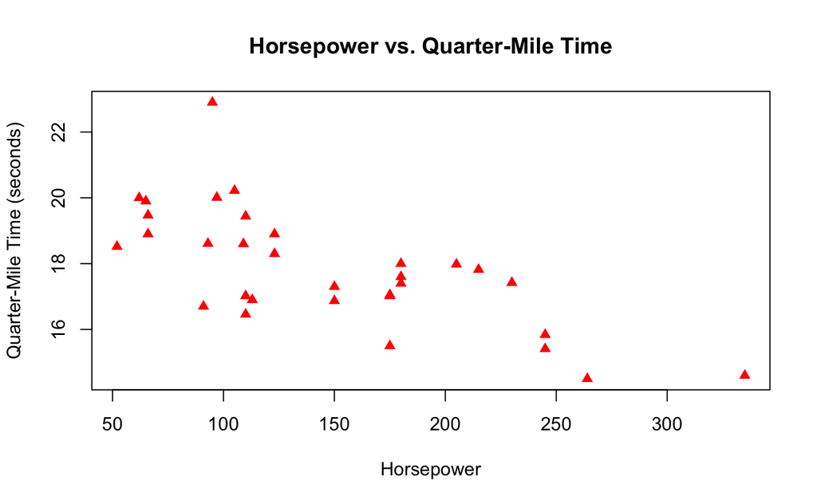

```r
plot(mtcars$hp, mtcars$qsec,
     main = "Horsepower vs. Quarter-Mile Time",
     xlab = "Horsepower",
     ylab = "Quarter-Mile Time (seconds)",
     pch = 17,
     col = "red")
```

2. Using the `iris` dataset (another built-in R dataset), create a scatter plot of sepal length vs. sepal width. Color the points based on the species.

```r
colors <- c("setosa" = "red", "versicolor" = "blue", "virginica" = "green")
species_colors <- colors[iris$Species]
colors[iris$Species]
```

[output not shown]

Solution:

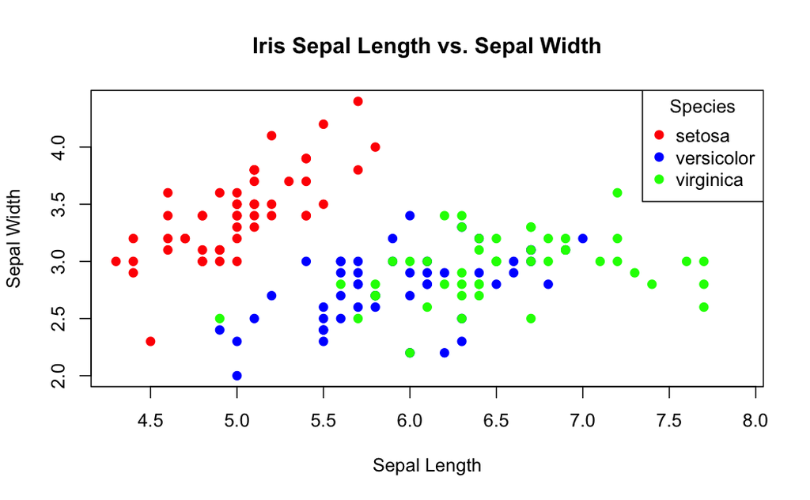

```r
# Create a color vector based on species
colors <- c("setosa" = "red", "versicolor" = "blue", "virginica" = "green")
species_colors <- colors[iris$Species]

plot(iris$Sepal.Length, iris$Sepal.Width,
     main = "Iris Sepal Length vs. Sepal Width",
     xlab = "Sepal Length",
     ylab = "Sepal Width",
     pch = 19,
     col = species_colors)

# Add a legend
legend("topright", legend = levels(iris$Species),
       col = colors, pch = 19, title = "Species")
```

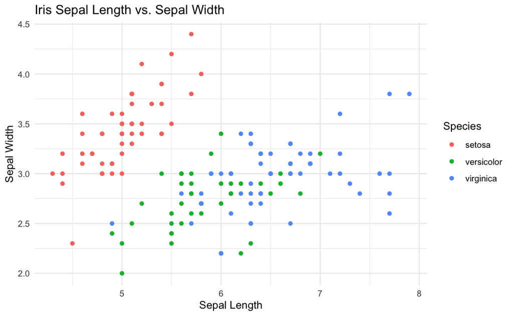

```r
ggplot(iris, aes(x = Sepal.Length, y = Sepal.Width, color = Species)) +
  geom_point() +
  labs(title = "Iris Sepal Length vs. Sepal Width",
       x = "Sepal Length",
       y = "Sepal Width",
       color = "Species") +
  theme_minimal()
```

## 2. Introduction to ggplot2

### Exercises

1. Using `ggplot2` and the `economics` dataset (comes with ggplot2), create a line plot of unemployment over time. Use the `date` column for the x-axis and `unemploy` for the y-axis. Add appropriate labels and a title.

Solution:

```r
ggplot(economics, aes(x = date, y = unemploy)) +
  geom_line(color = "blue") +
  labs(title = "Unemployment Over Time",
       x = "Date",
       y = "Number of Unemployed (in thousands)") +
  theme_minimal()
```

[output not shown]

2. With the `mpg` dataset (also included in ggplot2), create a scatter plot of engine displacement (`displ`) vs. highway miles per gallon (`hwy`). Color the points by the `class` of the vehicle. Add a title and appropriate axis labels.

Solution:

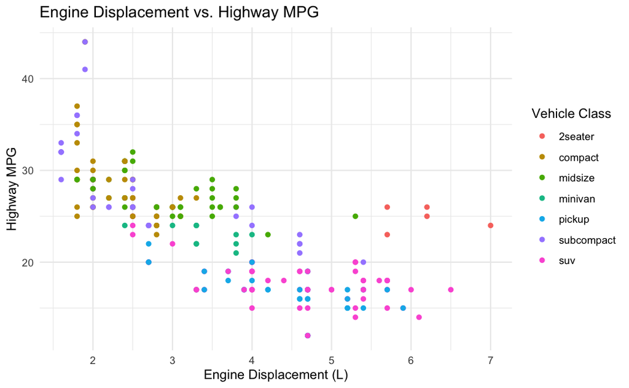

```r
ggplot(mpg, aes(x = displ, y = hwy, color = class)) +
  geom_point() +
  labs(title = "Engine Displacement vs. Highway MPG",
       x = "Engine Displacement (L)",
       y = "Highway MPG",
       color = "Vehicle Class") +
  theme_minimal()
```

## 3. Enhancing Plots with Color and Shape

### Exercises

1. Using the `diamonds` dataset (included in ggplot2), create a scatter plot of price vs. carat. Use color to represent the cut quality and shape to represent the clarity. Add appropriate labels and a title.

Solution:

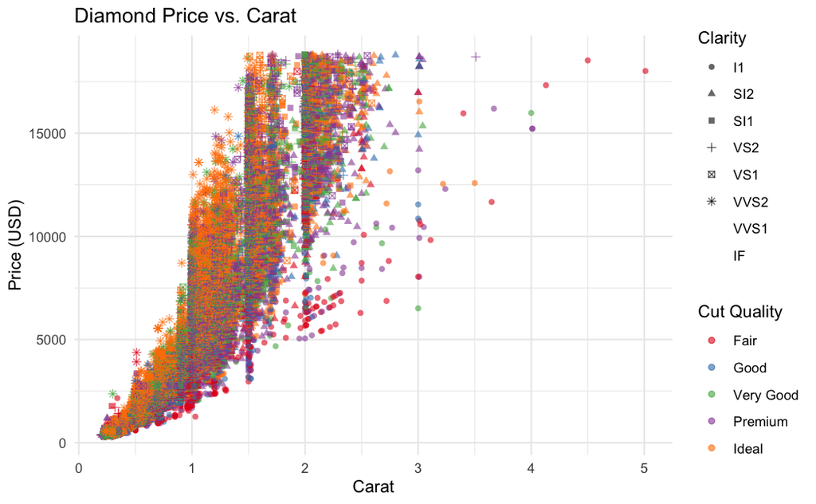

```r
ggplot(diamonds, aes(x = carat, y = price, color = cut, shape = clarity)) +
  geom_point(alpha = .6) +
  labs(title = "Diamond Price vs. Carat",
       x = "Carat",
       y = "Price (USD)",
       color = "Cut Quality",
       shape = "Clarity") +
  theme_minimal() +
  scale_color_brewer(palette = "Set1")
```

2. With the `iris` dataset, create a scatter plot of petal length vs. petal width. Use color to represent the species. Instead of using different shapes, vary the size of the points based on the sepal width. Add a legend for both color and size.

Solution:

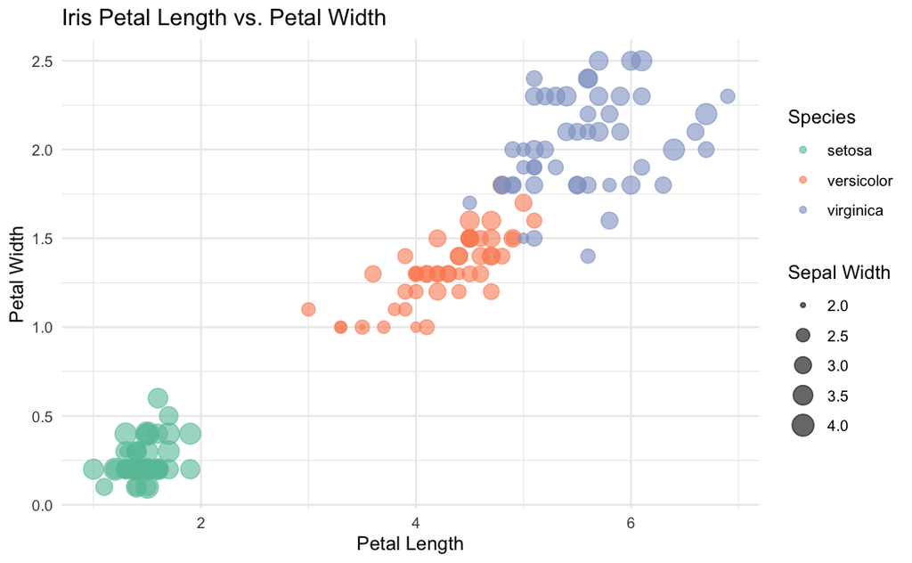

```r
ggplot(iris, aes(x = Petal.Length, y = Petal.Width, color = Species, size = Sepal.Width)) +
  geom_point(alpha = 0.6) +
  labs(title = "Iris Petal Length vs. Petal Width",
       x = "Petal Length",
       y = "Petal Width",
       color = "Species",
       size = "Sepal Width") +
  theme_minimal() +
  scale_color_brewer(palette = "Set2")
```

## 4. Creating Bar Plots

### Exercises

1. Using the `mpg` dataset, create a bar plot showing the count of cars for each manufacturer. Order the bars from highest to lowest count. Add appropriate labels and a title.

Solution:

```r
# Prepare data
manufacturer_counts <- mpg %>%
  count(manufacturer) %>%
  arrange(desc(n))

ggplot(manufacturer_counts, aes(x = reorder(manufacturer, -n), y = n)) +
  geom_bar(stat = "identity", fill = "skyblue") +
  labs(title = "Number of Cars by Manufacturer",
       x = "Manufacturer",
       y = "Count") +
  theme_minimal() +
  theme(axis.text.x = element_text(angle = 45, hjust = 1))
```

[output not shown]

2. With the `diamonds` dataset, create a stacked bar plot showing the proportion of different cuts (fair, good, very good, premium, ideal) for each clarity category. Use different colors for each cut. Add a legend and appropriate labels.

Solution:

```r
ggplot(diamonds, aes(x = clarity, fill = cut)) +
  geom_bar(position = "fill") +
  labs(title = "Proportion of Diamond Cuts by Clarity",
       x = "Clarity",
       y = "Proportion",
       fill = "Cut") +
  theme_minimal() +
  scale_fill_brewer(palette = "Set3")
```

[output not shown]

## 5. Box Plots for Comparing Distributions

### Exercises

1. Using the `diamonds` dataset, create a box plot showing the distribution of price for each cut category. Add color to the boxes based on the cut. Include appropriate labels and a title.

Solution:

```r
ggplot(diamonds, aes(x = cut, y = price, fill = cut)) +
  geom_boxplot() +
  labs(title = "Distribution of Diamond Prices by Cut",
       x = "Cut",
       y = "Price (USD)") +
  theme_minimal() +
  scale_fill_brewer(palette = "Set2") +
  theme(legend.position = "none")
```

[output not shown]

2. With the `gapminder` dataset (you may need to install the gapminder package), create a box plot showing the distribution of life expectancy for each continent. Arrange the continents in descending order of median life expectancy. Add color and appropriate labels.

Solution:

```r
# Install and load gapminder if not already installed
# install.packages("gapminder")
library(gapminder)

# Calculate median life expectancy for each continent
continent_order <- gapminder %>%
  group_by(continent) %>%
  summarize(median_lifeExp = median(lifeExp)) %>%
  arrange(desc(median_lifeExp)) %>%
  pull(continent)

ggplot(gapminder, aes(x = factor(continent, levels = continent_order), y = lifeExp, fill = continent)) +
  geom_boxplot() +
  labs(title = "Distribution of Life Expectancy by Continent",
       x = "Continent",
       y = "Life Expectancy (years)") +
  theme_minimal() +
  scale_fill_brewer(palette = "Set3") +
  theme(legend.position = "none")
```

[output not shown]

## 6. Histograms and Density Plots

### Exercises

1. Using the `diamonds` dataset, create a histogram of the ‘price’ variable. Experiment with different bin widths to see how it affects the visualization. Add a density curve on top of the histogram. Include appropriate labels and a title.

Solution:

```r
ggplot(diamonds, aes(x = price)) +
  geom_histogram(aes(y = ..density..), binwidth = 500, fill = "lightblue", color = "black") +
  geom_density(color = "red", size = 1) +
  labs(title = "Distribution of Diamond Prices",
       x = "Price (USD)",
       y = "Density") +
  theme_minimal()
```

[output not shown]

2. With the `faithful` dataset (built into R), create two density plots on the same graph: one for eruption duration and one for waiting time between eruptions. Use different colors for each density curve and add a legend. Normalize the scales so that both curves use the same y-axis. Add appropriate labels and a title.

Solution:

```r
# Prepare data
faithful_long <- faithful %>%
  pivot_longer(cols = everything(), names_to = "variable", values_to = "value")

ggplot(faithful_long, aes(x = value, fill = variable)) +
  geom_density(alpha = 0.5) +
  labs(title = "Density Plots of Old Faithful Eruptions",
       x = "Duration (minutes) / Waiting Time (minutes)",
       y = "Density",
       fill = "Variable") +
  scale_fill_manual(values = c("blue", "red"),
                    labels = c("Eruption duration", "Waiting time")) +
  theme_minimal()
```

[output not shown]

## 7. Faceting for Multi-panel Plots

### Exercises

1. Using the `diamonds` dataset, create a scatter plot of price vs. carat. Facet the plot by cut, creating a 2x3 grid of subplots. Color the points by clarity. Add a smooth trend line to each facet. Include appropriate labels and a title.

Solution:

```r
ggplot(diamonds, aes(x = carat, y = price, color = clarity)) +
  geom_point(alpha = 0.3) +
  geom_smooth(method = "lm", se = FALSE) +
  facet_wrap(~cut, nrow = 2) +
  labs(title = "Diamond Price vs. Carat by Cut and Clarity",
       x = "Carat",
       y = "Price (USD)",
       color = "Clarity") +
  theme_minimal() +
  scale_color_brewer(palette = "Set1")
```

[output not shown]

2. With the `mpg` dataset, create a box plot of highway fuel efficiency (hwy) for different car classes. Facet the plot by the number of cylinders (cyl). Color the boxes by the type of drive (drv). Arrange the facets in a single row. Add appropriate labels and a title.

Solution:

```r
ggplot(mpg, aes(x = class, y = hwy, fill = drv)) +
  geom_boxplot() +
  facet_wrap(~cyl, nrow = 1) +
  labs(title = "Highway MPG by Class, Cylinders, and Drive Type",
       x = "Vehicle Class",
       y = "Highway MPG",
       fill = "Drive Type") +
  theme_minimal() +
  theme(axis.text.x = element_text(angle = 45, hjust = 1)) +
  scale_fill_brewer(palette = "Set2")
```

[output not shown]